# DiaTrack

Solutions to diabetes data analyses and interpretation

## Hello, Daniel Rineald!

These are your diabetes management insights from **01/04/2024** to **29/04/2024**

**Good job! your TIR is of 79%**

Glucose Management Indicator (Estimated A1C): 6.56

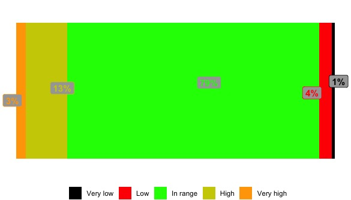

**Good meal control but numerous corrections**

Your postmeal glycemic control is good, however:

- You have higher risk of hyperglycemia beyond 2h after meal, suggesting problems with meals rich in protein or fat. Consider using square boluses.
- On average, you are using 13.7 boluses per day. Please consider refresh your carb ratio and carb measuraments.

Visit [counting carb guide help](https://www.cdc.gov/diabetes/managing/eat-well/diabetes-and-carbohydrates.html) for some guidance.

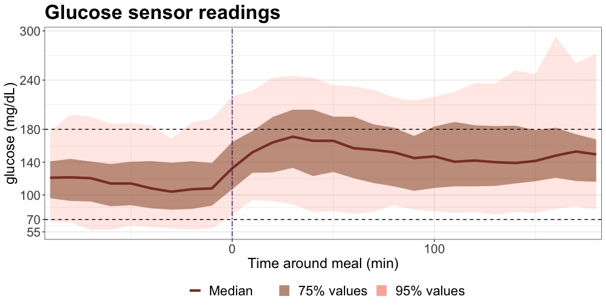

**Sundays are the days with poorest control**

Sundays also are the day of the week with highest risk of hypoglycemia, but Saturdays are worse for hyperglycemia.

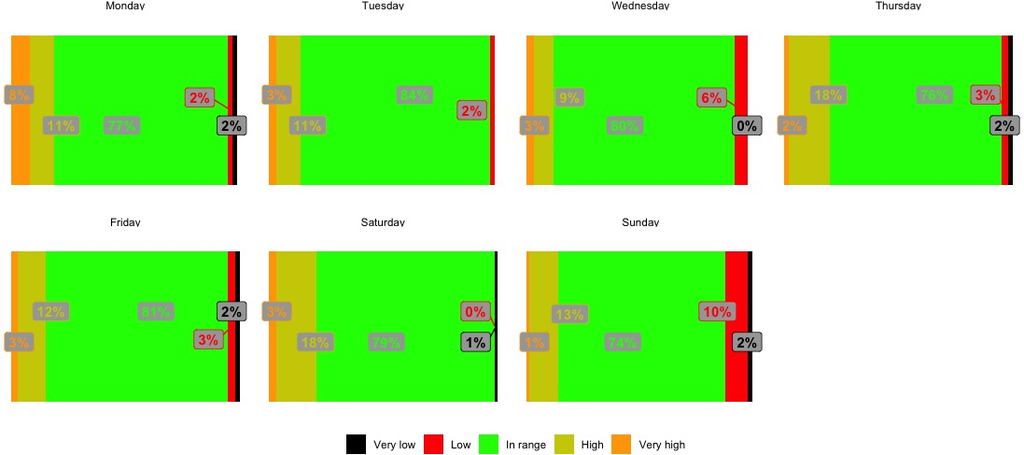

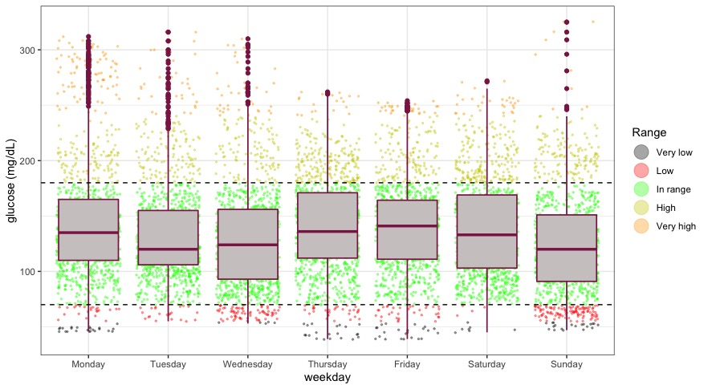

**Worst control happens during the night**

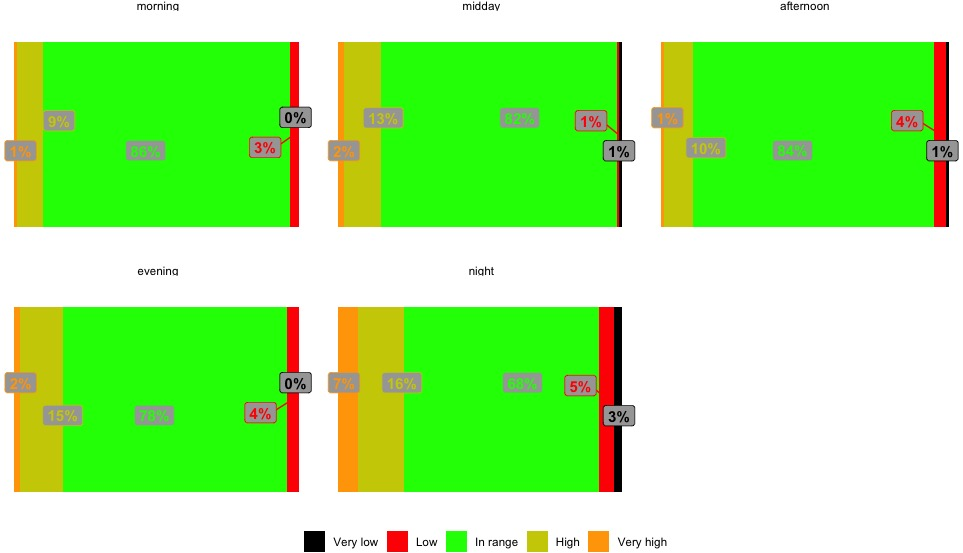

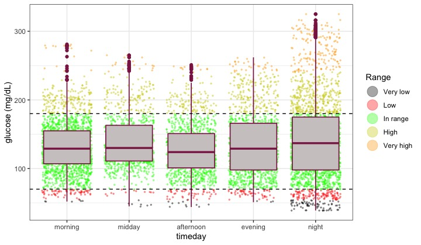

**Risk of hypoglycemia around noon and afternoons**

Beyond the night control, there is a high risk of hypoglycemia between 15h and 18h.  
Also, there is a mild risk at 13h and 22h, suggesting mild risk of hypoglycemia before meals. Consider checking your basal insulin.

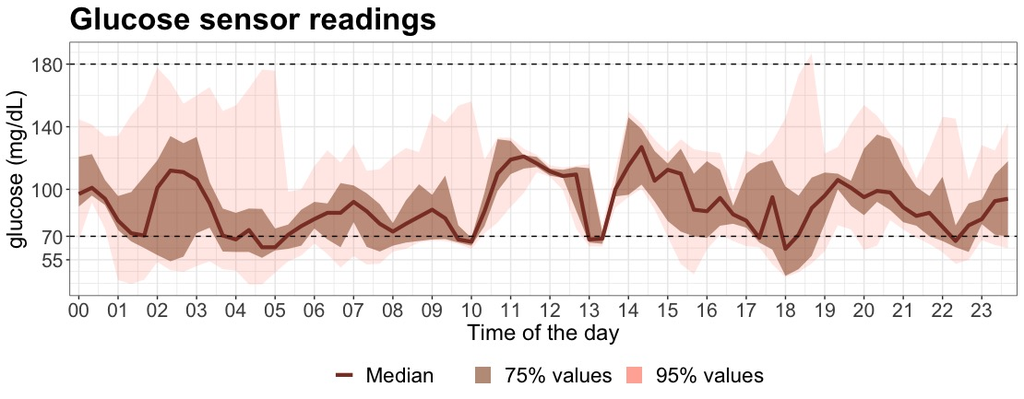

**Afternoon hypoglycemic events tend to be overcorrected**

Often, hypoglycemic events between 15 and 18h are overcorrected, leading to a mild hyperglycemia.

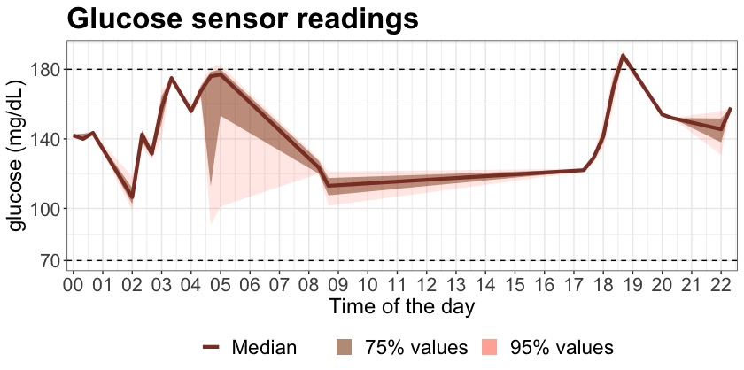